# HW 03 - Great Lakes Fish Datasets

Insert your name here

Insert date here

## Load packages and data

```r
library(tidyverse)
```

```r
catch_data <- readr::read_csv('https://raw.githubusercontent.com/rfordatascience/tidytuesday/master/data/2021/2021-06-08/fishing.csv')

fish_stock <- read_csv("data/great-lakes-fish-stock.csv")
```

## Exercises

### Exercise 1

```r
catch_data <- catch_data %>%
  select(year, lake, species, region, values)
```

```r
fish_stock <- fish_stock %>%
  select(-NO_STOCKED, -AGEMONTH)
```

**Half point for each correct and labeled code chunk. selection method can vary as along as correct variables are selected (MAX 1)**

### Exercise 2

```r
glimpse(catch_data)
```

```
## Rows: 65,706
## Columns: 5
## $ year    <dbl> 1991, 1991, 1991, 1991, 1991, 1991, 1992, 1992, 1992, 1992, 19…
## $ lake    <chr> "Erie", "Erie", "Erie", "Erie", "Erie", "Erie", "Erie", "Erie"…
## $ species <chr> "American Eel", "American Eel", "American Eel", "American Eel"…
## $ region  <chr> "Michigan (MI)", "New York (NY)", "Ohio (OH)", "Pennsylvania (…
## $ values  <dbl> 0, 0, 0, 0, 0, 1, 0, 0, 0, 0, 0, 0, 0, 0, 0, 0, 0, 0, 0, 0, 0,…
```

```r
glimpse(fish_stock)
```

```
## Rows: 56,232
## Columns: 6
## $ YEAR       <dbl> 1950, 1952, 1952, 1952, 1953, 1953, 1953, 1953, 1953, 1954,…
## $ MONTH      <dbl> NA, 4, 9, NA, 5, 10, NA, NA, NA, 6, 10, NA, NA, NA, NA, NA,…
## $ LAKE       <chr> "MI", "SU", "SU", "SU", "SU", "SU", "SU", "SU", "SU", "SU",…
## $ STATE_PROV <chr> "ON", "WI", "WI", "MI", "WI", "WI", "MI", "MI", "ON", "WI",…
## $ SPECIES    <chr> "LAT", "LAT", "LAT", "LAT", "LAT", "LAT", "LAT", "LAT", "LA…
## $ WEIGHT     <dbl> NA, 816.78, 870.00, 588.29, 1442.47, 664.90, 902.71, 695.37…
```

**Half point for using glimpse in labeled code chunk (MAX 0.5)**

### Exercise 3

```r
catch_data <- catch_data %>%
  filter(region == "U.S. Total",
         species == "Chinook Salmon",
         lake == "Michigan")
```

```r
fish_stock <- fish_stock %>%
  filter(STATE_PROV %in% c("MI", "WI", "IL", "IN"),
         SPECIES == "CHS",
         LAKE == "MI")
```

**Half point for each correct chunk (MAX 1)**

### Exercise 4

There are now 17 rows in the `catch_data` dataset, and 2395 rows in the `fish_stock` dataset. The earliest year in the `catch_data` dataset is 1992 and the most recent year was 2015. The earliest year in the `fish_stock` dataset is 1967 and the most recent year was 2018.

**Half point for each correct statement using inline code (MAX 1.5)**

### Exercise 5

```r
fish_stock_yearly <- fish_stock %>%
  group_by(YEAR) %>%
  summarize(STOCK_WEIGHT_YR = sum(WEIGHT, na.rm = TRUE))
```

**Half point each for label, correct use of group_by and correct use of summarize calculation, and assigning to correct new object name (MAX 1.5)**

### Code chunks provided

```r
fish_stock_yearly <- fish_stock_yearly %>%
  rename(year = YEAR) %>%
  mutate(stock_weight_yr_lbs = as.integer(STOCK_WEIGHT_YR * 0.454 / 1000)) %>% # 1 lb = 1 kg * 0.454
  select(year, stock_weight_yr_lbs)
```

```r
catch_data <- catch_data %>%
  rename(catch_weight_yr_lbs = values)
```

### Exercise 6

```r
catch_data %>%
  left_join(fish_stock_yearly)
```

```
## # A tibble: 17 × 6
##     year lake     species        region     catch_weight_yr_lbs stock_weight_yr…
##    <dbl> <chr>    <chr>          <chr>                    <dbl>            <int>
##  1  1992 Michigan Chinook Salmon U.S. Total                   7               12
##  2  1993 Michigan Chinook Salmon U.S. Total                   6               10
##  3  1994 Michigan Chinook Salmon U.S. Total                  43               12
##  4  1995 Michigan Chinook Salmon U.S. Total                  57               13
##  5  1996 Michigan Chinook Salmon U.S. Total                  47               19
##  6  1997 Michigan Chinook Salmon U.S. Total                  29               17
##  7  1998 Michigan Chinook Salmon U.S. Total                  27               16
##  8  1999 Michigan Chinook Salmon U.S. Total                   8               15
##  9  2007 Michigan Chinook Salmon U.S. Total                   4               13
## 10  2008 Michigan Chinook Salmon U.S. Total                   5               12
## 11  2009 Michigan Chinook Salmon U.S. Total                   3               12
## 12  2010 Michigan Chinook Salmon U.S. Total                   2               12
## 13  2011 Michigan Chinook Salmon U.S. Total                   7               11
## 14  2012 Michigan Chinook Salmon U.S. Total                   3               11
## 15  2013 Michigan Chinook Salmon U.S. Total                   3                7
## 16  2014 Michigan Chinook Salmon U.S. Total                   1                8
## 17  2015 Michigan Chinook Salmon U.S. Total                   0                8
```

Rows from `catch_data` were retained and `stock_weight_yr_lbs` was added for each row.

```r
catch_data %>%
  right_join(fish_stock_yearly)
```

```
## # A tibble: 52 × 6
##     year lake     species        region     catch_weight_yr_lbs stock_weight_yr…
##    <dbl> <chr>    <chr>          <chr>                    <dbl>            <int>
##  1  1992 Michigan Chinook Salmon U.S. Total                   7               12
##  2  1993 Michigan Chinook Salmon U.S. Total                   6               10
##  3  1994 Michigan Chinook Salmon U.S. Total                  43               12
##  4  1995 Michigan Chinook Salmon U.S. Total                  57               13
##  5  1996 Michigan Chinook Salmon U.S. Total                  47               19
##  6  1997 Michigan Chinook Salmon U.S. Total                  29               17
##  7  1998 Michigan Chinook Salmon U.S. Total                  27               16
##  8  1999 Michigan Chinook Salmon U.S. Total                   8               15
##  9  2007 Michigan Chinook Salmon U.S. Total                   4               13
## 10  2008 Michigan Chinook Salmon U.S. Total                   5               12
## # … with 42 more rows
```

Rows from `fish_stock_yearly` were retained. For any rows that were missing in `catch_data`, the `catch_weight_yr_lbs` column was filled with NAs/missing values.

```r
catch_data %>%
  inner_join(fish_stock_yearly)
```

```
## # A tibble: 17 × 6
##     year lake     species        region     catch_weight_yr_lbs stock_weight_yr…
##    <dbl> <chr>    <chr>          <chr>                    <dbl>            <int>
##  1  1992 Michigan Chinook Salmon U.S. Total                   7               12
##  2  1993 Michigan Chinook Salmon U.S. Total                   6               10
##  3  1994 Michigan Chinook Salmon U.S. Total                  43               12
##  4  1995 Michigan Chinook Salmon U.S. Total                  57               13
##  5  1996 Michigan Chinook Salmon U.S. Total                  47               19
##  6  1997 Michigan Chinook Salmon U.S. Total                  29               17
##  7  1998 Michigan Chinook Salmon U.S. Total                  27               16
##  8  1999 Michigan Chinook Salmon U.S. Total                   8               15
##  9  2007 Michigan Chinook Salmon U.S. Total                   4               13
## 10  2008 Michigan Chinook Salmon U.S. Total                   5               12
## 11  2009 Michigan Chinook Salmon U.S. Total                   3               12
## 12  2010 Michigan Chinook Salmon U.S. Total                   2               12
## 13  2011 Michigan Chinook Salmon U.S. Total                   7               11
## 14  2012 Michigan Chinook Salmon U.S. Total                   3               11
## 15  2013 Michigan Chinook Salmon U.S. Total                   3                7
## 16  2014 Michigan Chinook Salmon U.S. Total                   1                8
## 17  2015 Michigan Chinook Salmon U.S. Total                   0                8
```

Rows present in both `catch_data` and `fish_stock_yearly` were retained and `stock_weight_yr_lbs` was added for each row. Same output at `left_join()` but for slightly different reason.

```r
catch_data %>%
  full_join(fish_stock_yearly)
```

```
## # A tibble: 52 × 6
##     year lake     species        region     catch_weight_yr_lbs stock_weight_yr…
##    <dbl> <chr>    <chr>          <chr>                    <dbl>            <int>
##  1  1992 Michigan Chinook Salmon U.S. Total                   7               12
##  2  1993 Michigan Chinook Salmon U.S. Total                   6               10
##  3  1994 Michigan Chinook Salmon U.S. Total                  43               12
##  4  1995 Michigan Chinook Salmon U.S. Total                  57               13
##  5  1996 Michigan Chinook Salmon U.S. Total                  47               19
##  6  1997 Michigan Chinook Salmon U.S. Total                  29               17
##  7  1998 Michigan Chinook Salmon U.S. Total                  27               16
##  8  1999 Michigan Chinook Salmon U.S. Total                   8               15
##  9  2007 Michigan Chinook Salmon U.S. Total                   4               13
## 10  2008 Michigan Chinook Salmon U.S. Total                   5               12
## # … with 42 more rows
```

All rows present in either `catch_data` or `fish_stock_yearly` were retained and NAs were added for any missing stock or catch data. Same output at `right_join()` but for slightly different reason.

**First 4: 1/4 point for each correct pipeline AND explanation of which rows are retained by function.**

```r
catch_data %>%
  anti_join(fish_stock_yearly)
```

```
## # A tibble: 0 × 5
## # … with 5 variables: year <dbl>, lake <chr>, species <chr>, region <chr>,
## #   catch_weight_yr_lbs <dbl>
```

Zero rows were retained as none were present in `catch_data` that did not also appear in `fish_stock_yearly` were retained.

```r
fish_stock_yearly %>%
  anti_join(catch_data)
```

```
## # A tibble: 35 × 2
##     year stock_weight_yr_lbs
##    <dbl>               <int>
##  1  1967                   0
##  2  1968                   0
##  3  1969                   0
##  4  1970                   0
##  5  1971                   0
##  6  1972                   0
##  7  1973                   0
##  8  1974                   0
##  9  1975                   0
## 10  1976                   0
## # … with 25 more rows
```

All rows were retained from `fish_stock_yearly` that were not present in `catch_data`.

**Last 2: 1.4 point for each correct explanation of which rows were retained (MAX 1.5)**

### Exercise 7

```r
catch_data %>%
  left_join(fish_stock_yearly) %>%
  pivot_longer(names_to = "activity",
               values_to = "weight_lbs",
               cols = 5:6)
```

```
## # A tibble: 34 × 6
##     year lake     species        region     activity            weight_lbs
##    <dbl> <chr>    <chr>          <chr>      <chr>                    <dbl>
##  1  1992 Michigan Chinook Salmon U.S. Total catch_weight_yr_lbs          7
##  2  1992 Michigan Chinook Salmon U.S. Total stock_weight_yr_lbs         12
##  3  1993 Michigan Chinook Salmon U.S. Total catch_weight_yr_lbs          6
##  4  1993 Michigan Chinook Salmon U.S. Total stock_weight_yr_lbs         10
##  5  1994 Michigan Chinook Salmon U.S. Total catch_weight_yr_lbs         43
##  6  1994 Michigan Chinook Salmon U.S. Total stock_weight_yr_lbs         12
##  7  1995 Michigan Chinook Salmon U.S. Total catch_weight_yr_lbs         57
##  8  1995 Michigan Chinook Salmon U.S. Total stock_weight_yr_lbs         13
##  9  1996 Michigan Chinook Salmon U.S. Total catch_weight_yr_lbs         47
## 10  1996 Michigan Chinook Salmon U.S. Total stock_weight_yr_lbs         19
## # … with 24 more rows
```

**Half point each for correctly completing left_join and pivot_longer (MAX 1.0)**

### Exercise 8

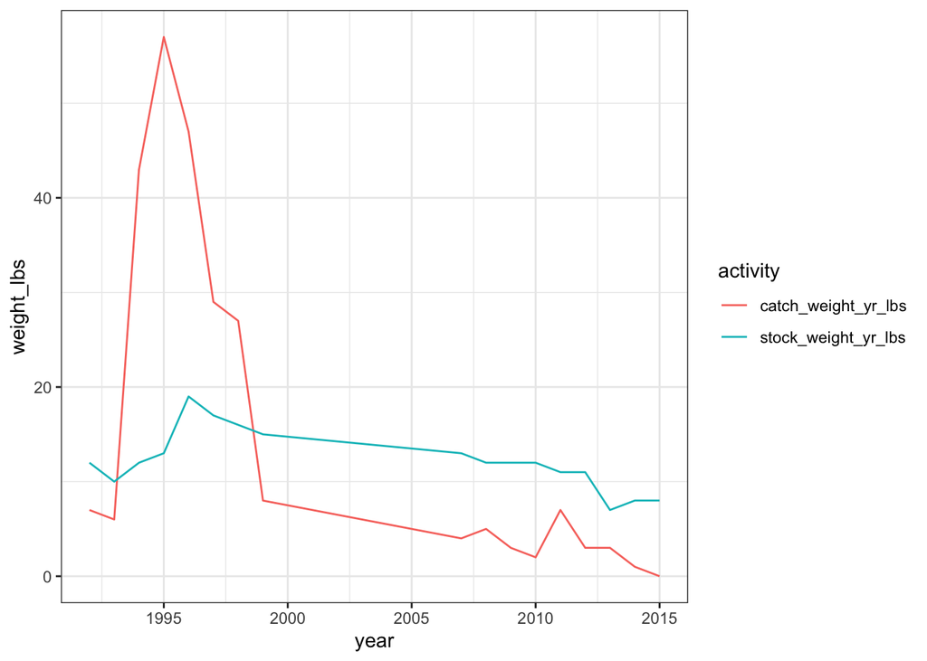

```r
catch_data %>%
  left_join(fish_stock_yearly) %>%
  pivot_longer(names_to = "activity",
               values_to = "weight_lbs",
               cols = 5:6) %>%
  ggplot(aes(x = year, y = weight_lbs, color = activity)) +
  geom_line() +
  theme_bw()
```

The stocking rate has stayed fairly constant sinc ehte 90s, whereas the catch rate peaked sharply in the mid-90s and has dropped since, to less than 1000 lbs in 2015.

**Half point each for mapping aesthetics, adding geometries, adding theme layer, and interpreting (MAX 2)*